# Week 4: home assignment

Manuel Trombetta

2026-02-05

### Load libraries

```r
library(tidyverse)
library(broom)
library(car)
library(languageR)
```

### Load data from “languageR” library

```r
data("dative")
head(dative)
```

```
##   Speaker Modality  Verb SemanticClass LengthOfRecipient AnimacyOfRec
## 1    <NA>  written  feed             t                 1      animate
## 2    <NA>  written  give             a                 2      animate
## 3    <NA>  written  give             a                 1      animate
## 4    <NA>  written  give             a                 1      animate
## 5    <NA>  written offer             c                 2      animate
## 6    <NA>  written  give             a                 2      animate
##   DefinOfRec   PronomOfRec LengthOfTheme AnimacyOfTheme DefinOfTheme
## 1   definite    pronominal            14      inanimate   indefinite
## 2   definite nonpronominal             3      inanimate   indefinite
## 3   definite nonpronominal            13      inanimate     definite
## 4   definite    pronominal             5      inanimate   indefinite
## 5   definite nonpronominal             3      inanimate     definite
## 6   definite nonpronominal             4      inanimate   indefinite
##   PronomOfTheme RealizationOfRecipient AccessOfRec AccessOfTheme
## 1 nonpronominal                     NP       given           new
## 2 nonpronominal                     NP       given           new
## 3 nonpronominal                     NP       given           new
## 4 nonpronominal                     NP       given           new
## 5 nonpronominal                     NP       given           new
## 6 nonpronominal                     NP       given           new
```

### Formulating null hypotheses

- **H0<sub>1</sub> (Animacy)**  
  *The animacy of the recipient does not affect the choice between PP and NP.*
- **H0<sub>2</sub> (Length)**  
  *The length of the recipient does not affect the choice between PP and NP.*

### Creation of the logistic model

First, the dataset was loaded and the response variable (RealizationOfRecipient) was converted into a factor. In R, a factor is used to represent categorical variables; in this case, the response has two possible categories (PP and NP). A logistic regression model with a logit link was then fitted, using animacy and length of the recipient as predictors. This model estimates how these factors affect the probability of selecting the PP construction.

```r
# using factor on RealizationOfRecipient:
dative <- dative %>%
  mutate(RealizationOfRecipient = factor(RealizationOfRecipient))

dative_glm <- glm(RealizationOfRecipient ~ AnimacyOfRec + LengthOfRecipient,
                  data = dative,
                  family="binomial")

vif(dative_glm)
```

```
##      AnimacyOfRec LengthOfRecipient
##          1.000444          1.000444
```

```r
summary(dative_glm)
```

```
##
## Call:
## glm(formula = RealizationOfRecipient ~ AnimacyOfRec + LengthOfRecipient,
##     family = "binomial", data = dative)
##
## Coefficients:
##                       Estimate Std. Error z value Pr(>|z|)
## (Intercept)           -2.40369    0.08080 -29.750  < 2e-16 ***
## AnimacyOfRecinanimate  1.02035    0.15258   6.687 2.28e-11 ***
## LengthOfRecipient      0.68456    0.03845  17.806  < 2e-16 ***
## ---
## Signif. codes:  0 '***' 0.001 '**' 0.01 '*' 0.05 '.' 0.1 ' ' 1
##
## (Dispersion parameter for binomial family taken to be 1)
##
##     Null deviance: 3741.1  on 3262  degrees of freedom
## Residual deviance: 3062.3  on 3260  degrees of freedom
## AIC: 3068.3
##
## Number of Fisher Scoring iterations: 5
```

```r
tidy(dative_glm)
```

```
## # A tibble: 3 × 5
##   term                  estimate std.error statistic   p.value
##   <chr>                    <dbl>     <dbl>     <dbl>     <dbl>
## 1 (Intercept)             -2.40     0.0808    -29.8  1.73e-194
## 2 AnimacyOfRecinanimate    1.02     0.153       6.69 2.28e- 11
## 3 LengthOfRecipient        0.685    0.0384     17.8  6.36e- 71
```

### Interpretation of the results

Both predictors show significant effects.  
Animacy has a positive and significant effect: inanimate recipients are more likely to occur in the PP construction (Estimate = 1.02, SE = 0.15, p < 2.28e-11).  
Length of the recipient also has a strong positive effect (Estimate = 0.68, SE = 0.04, p < 2e-16), indicating that longer recipients favor the PP construction.

Both null hypotheses are therefore rejected (the p-value is less than 0.05). Keeping animacy constant, the probability of the PP construction increases substantially with recipient length.

### Assessment of the probablity of the *PP category*

```r
intercept <- coef(dative_glm)[[1]]
slope_length <- coef(dative_glm)[[3]]
slope_anim <- coef(dative_glm)[[2]]

plogis(intercept + slope_length*5 + slope_anim*0) # 5-word recipient
```

```
## [1] 0.7348028
```

```r
plogis(intercept + slope_length*3 + slope_anim*0) # 3-word recipient
```

```
## [1] 0.4133828
```

```r
plogis(intercept + slope_length*1 + slope_anim*0) # 1-word recipient
```

```
## [1] 0.1519838
```

For a five-word recipient, the model predicts a high probability of the PP construction (about 73%), even when the recipient is animate.As for 3-word recipients and 1-word recipients, the probabilities drop to 41% and 15% respectively.

### EXTRA: Visualisation of predicted probabilities

```r
data_anim <- data.frame(
  LengthOfRecipient = seq(1,6, by=1),
  AnimacyOfRec = "animate"
)

data_inanim <- data.frame(
  LengthOfRecipient = seq(1,6, by=1),
  AnimacyOfRec = "inanimate"
)

probabilities_anim <- predict(
  dative_glm,
  newdata = data_anim,
  type = "response"
)

probabilities_inanim <- predict(
  dative_glm,
  newdata = data_inanim,
  type = "response"
)

#check
head(probabilities_anim)
```

```
##         1         2         3         4         5         6
## 0.1519838 0.2622006 0.4133828 0.5828697 0.7348028 0.8460164
```

```r
head(probabilities_inanim)
```

```
##         1         2         3         4         5         6
## 0.3320828 0.4964460 0.6615809 0.7949313 0.8848798 0.9384303
```

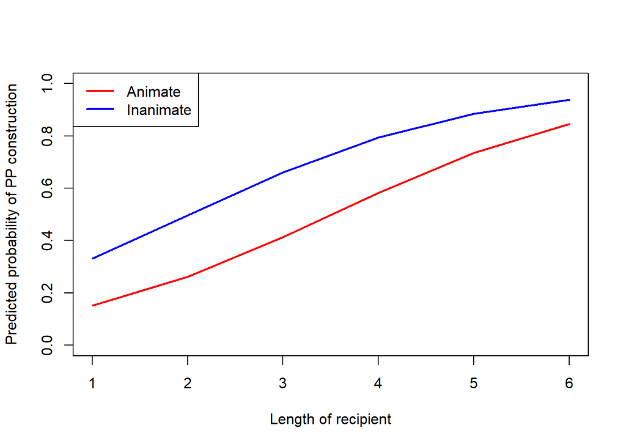

```r
# Visualisation of predicted probabilities for animate and inanimate recipients.
plot(
  data_anim$LengthOfRecipient,
  probabilities_anim,
  type = "l",
  lwd = 2,
  col = "red",
  xlab = "Length of recipient",
  ylab = "Predicted probability of PP construction",
  ylim = c(0, 1)
)

lines(
  data_inanim$LengthOfRecipient,
  probabilities_inanim,
  lwd = 2,
  col = "blue"
)

legend(
  "topleft",
  legend = c("Animate", "Inanimate"),
  col = c("red", "blue"),
  lwd = 2
)
```

The curves illustrate the predictions of the logistic regression model, highlighting a positive effect of recipient length and a strong effect of animacy on the choice of the PP construction.

source: https://www.r-bloggers.com/2023/10/plotting-a-logistic-regression-in-base-r/